# Telethon Kids Institute

July 7, 2018

## Template Ioslide Walkthrough

## Titles

See ioslides manual at: https://rmarkdown.rstudio.com/ioslides_presentation_format

Titles with a single # will generate a blank screen containing the title only, useful for section breaks. Titles with two ## will start a new slide with the following text as the heading.

## Titles

### Subtitles

You can add a subtitle to a slide or section by including text after the pipe (|) character. For example:

```r
## Titles | Subtitles
```

## Incremental Bullets

## Incremental Bullets

- Format the front matter with `incremental: true` to enable incremental bullets.

```
 output:
  ioslides_presentation:
   incremental: true
```

If you want to render bullets incrementally for some slides but not others you can use this syntax:  
> - like  
> - this

## Incremental Bullets

Otherwise use syntax:  
- like  
- this

and bullets will appear:

- like
- this

## Images

## A R generated plot

To centre an image include the following in the r chunk header:

`{r, echo = FALSE, out.extra = ‘class=“centre”’}`

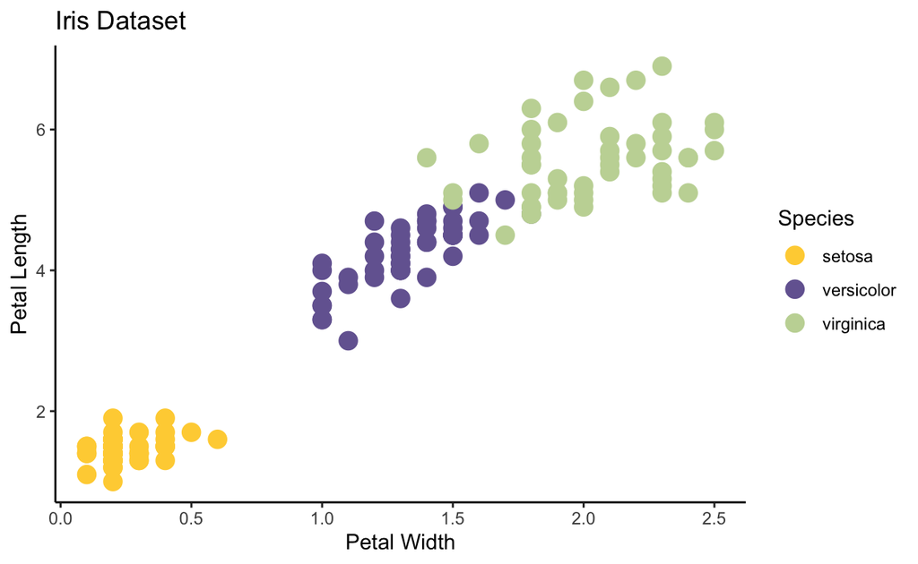

## A linked image

An image can be added, either from a local file or external URL, by using the `include_graphics()` function inside a chunk:

````
```{r, echo = FALSE, out.extra = ‘class=“centre” style=“width: 300px;”’}
 include_graphics(“assets/images/logo800.jpg”)

 ```
````

[figure not shown]

## In-line figures

[figure not shown]

In-line figures can be placed in a paragraphy by including the following code into the R chunk header:

`{r, out.extra = ‘style=“float: left; width: 250px; margin: 10px;”’}`

`float: left;` can be either left or right. The image size can be manipultaed by changing the `width: 250px;` text, and the margin size around the image can be manipulated with `margin: 10px;`.

## Slide modifications

## 2 Columns

### Layout

Slides can be modified by placing content inside HTML div tags with class arguments:

`<div class=“col2”>…</div>`

**1** one  
**2** two  
**3** three  
**4** four  
**5** five  
**6** six  
**7** seven  
**8** eight  
**9** nine

## 3 Columns

### Layout

`<div class=“col3”>…</div>`

**1** one  
**2** two  
**3** three  
**4** four  
**5** five  
**6** six  
**7** seven  
**8** eight  
**9** nine

## Text Size

### Formatting

Font-size can be manipulated within a slide by placing the text within `div` tags with class=“small” or class=“large”.

This is an example of small text:

`<div class=“small”>…</div>`

This is the normal default font size.

This is an example of large text:

`<div class=“large”>…</div>`

## Multiple Formatting Tags

Multiple classes can be assigned to a single div:

`<div class=“col3 large”>…</div>`

**1** one  
**2** two  
**3** three  
**4** four  
**5** five  
**6** six  
**7** seven  
**8** eight  
**9** nine